# Pan TCR analysis

University Hospital Basel – Molecular Diagnostic Unit

06 December, 2022

## Sample Info

Sample ID: W3525_B2022.50915_v1_20221204101403744

## Kommentar

Ein dominantes Rearrangement wird definiert, wenn die zugehoerigen Sequenzen mehr als 2.5% der gesamten Reads und mehr als das 10-fache des polyklonalen Hintergrunds betragen (Empfehlung von Arcila, Maria E. et.al. 2019, PMID: 30590126).

## Methodik

DNA wurde vom eingesandten Material extrahiert. Amplifikation der Zielsequenzen und Parallelsequenzierung (Next-Generation Sequencing) den genomischen T-Zell-Rezeptors (TCR) Gamma und Beta-Regionen auf der Ion Torrent S5 Plattform unter Verwendung des Ion Torrent TCR Pan-Clonality Assays. Der Assay ermöglicht die Bestimmung der Sequenzen der complementarity-determining Region 3 (CDR3) der TCR-Gamma und Beta-Kette. Der Oncomine TCR Pan-Clonality Assay verwendet Multiplex-Ion-Ampliseq-Primers, die auf die FR3-Region des variablen Gens (V-Gen) und die joining Gensegmente (J-Gen) der TCR Gamma und Beta-Rearrangements abzielen und ein ~75-100 bp-Amplikon produzieren. Datenanalyse mittels Torrent Suite und Ion Reporter Software.

Das molekularpathologische Labor nimmt im Rahmen der Qualitätssicherung regelmässig an Ringversuchen von EMQN und QuiP mit Erfolg teil.

Für weitere Informationen siehe: www.unispital-basel.ch/molpathologie

- Total Read Count = 497841
- Total Number of Clones Detected = 841
- Largest clone frequency = 1.6%
- Background:
  - rank2 clone frequency = 1.4%
  - rank3 clone frequency = 1.3%
  - rank4 clone frequency = 1.2%
  - rank5 clone frequency = 1.1%
- Ratio largest clone to:
  - rank2 clone frequency = 1.1x
  - rank3 clone frequency = 1.3x
  - rank4 clone frequency = 1.4x
  - rank5 clone frequency = 1.5x

#### Top 25 Clones Summary Table

| Variable | Joining | CDR3.AA | CDR3.NT | Total.Counts | Frequency | Rank |
| --- | --- | --- | --- | --- | --- | --- |
| IGHV3-23 | IGHJ4 | AKEKGAVAGAFDY | GCGAAAGAGAAAGGAGCAGTGGCTGGAGCTTTTGACTAC | 8014 | 0.016 | 1 |
| IGHV3-11 | IGHJ6 | ARDRVTTFGMDV | GCGAGAGATCGTGTGACTACTTTCGGTATGGACGTC | 6972 | 0.014 | 2 |
| IGHV4-34 | IGHJ4 | ARHFYDRFDF | GCGAGACACTTCTATGACCGCTTTGACTTC | 6230 | 0.013 | 3 |
| IGHV2-70 | IGHJ4 | ARMMDTTMANRYYFDY | GCACGGATGATGGATACAACTATGGCTAACCGGTACTACTTTGACTAC | 5792 | 0.012 | 4 |
| IGHV5-51 | IGHJ4 | ARHYDSSGYYPYFDY | GCGAGACATTATGATAGTAGTGGTTATTACCCTTACTTTGACTAC | 5436 | 0.011 | 5 |
| IGHV3-11 | IGHJ4 | ARVLAGSWGPFDY | GCGAGAGTGCTTGCTGGGAGCTGGGGGCCCTTTGACTAC | 3970 | 0.008 | 6 |
| IGHV1-18 | IGHJ4 | ARDGAGRGTLDY | GCGAGAGATGGGGCAGGGCGTGGTACACTTGACTAC | 3885 | 0.008 | 7 |
| IGHV2-5 | IGHJ6 | AHISSLNYYYGMDV | GCACACATCTCGTCCCTCAACTACTATTACGGTATGGACGTC | 3852 | 0.008 | 8 |
| IGHV3-74 | IGHJ4 | ARDVGGADSH | GCCAGAGATGTAGGGGGTGCTGACTCCCAC | 3717 | 0.007 | 9 |
| IGHV3-23 | IGHJ6 | TKNLSGWDYHGMDV | ACGAAGAACCTTAGTGGCTGGGACTACCACGGTATGGACGTC | 3464 | 0.007 | 10 |
| IGHV5-10-1 | IGHJ4 | ATVLREGAYSYGLPFDY | GCGACCGTCCTGAGGGAGGGCGCATACAGCTACGGTCTTCCATTTGACTAC | 3337 | 0.007 | 11 |
| IGHV6-1 | IGHJ4 | ARDPGSYYVEGGAL | GCAAGAGATCCTGGGAGCTACTACGTTGAAGGGGGCGCACTA | 3242 | 0.007 | 12 |
| IGHV3-21 | IGHJ5 | ARSPWVGGTWFDT | GCGAGGTCCCCTTGGGTAGGGGGGACCTGGTTCGACACC | 3180 | 0.006 | 13 |
| IGHV5-51 | IGHJ5 | ARLSYSSSWDGGWFDP | GCGAGACTCTCGTATAGCAGCAGCTGGGATGGTGGGTGGTTCGACCCC | 3146 | 0.006 | 14 |
| IGHV3-9 | IGHJ4 | AKGARDAFDY | GCAAAAGGCGCCAGGGATGCCTTTGACTAC | 3134 | 0.006 | 15 |
| IGHV3-11 | IGHJ6 | ARIAVFFGMDV | GCGAGAATAGCCGTATTCTTCGGTATGGACGTC | 2934 | 0.006 | 16 |
| IGHV3-11 | IGHJ4 | VRARYSSSSGGYYFDY | GTGAGAGCACGTTACAGCAGTTCGTCCGGAGGTTACTACTTTGACTAC | 2880 | 0.006 | 17 |
| IGHV4-34 | IGHJ5 | ARGFGYQLLNWFDP | GCGAGAGGTTTTGGATACCAGCTGCTAAACTGGTTCGACCCC | 2827 | 0.006 | 18 |
| IGHV3-11 | IGHJ6 | ARNRVAEDGFYGMDV | GCGAGAAATCGGGTAGCCGAAGATGGATTCTACGGTATGGACGTC | 2724 | 0.005 | 19 |
| IGHV3-74 | IGHJ4 | ARDVAGADSH | GCCAGAGATGTGGCGGGTGCTGACTCCCAC | 2588 | 0.005 | 20 |
| IGHV3-11 | IGHJ4 | ARVYSSSWTFDY | GCGAGAGTTTATAGCAGCAGCTGGACCTTTGACTAC | 2575 | 0.005 | 21 |
| IGHV4-34 | IGHJ6 | ARGYYDSGGYWTYYYYGMDV | GCGAGAGGTTACTACGATAGTGGTGGTTATTGGACCTACTACTACTACGGTATGGACGTC | 2554 | 0.005 | 22 |
| IGHV3-23 | IGHJ4 | AKVLDYGDYDGALT | GCGAAAGTCCTAGACTACGGTGACTACGACGGAGCCTTGACTA | 2524 | 0.005 | 23 |
| IGHV2-70 | IGHJ6 | ARMSLERGYYYYAMDV | GCACGGATGAGCCTGGAACGCGGCTACTACTACTACGCTATGGACGTC | 2451 | 0.005 | 24 |
| IGHV3-9 | IGHJ6 | AKDIQPTTMYGMDV | GCAAAGGATATCCAACCAACTACCATGTACGGAATGGACGTC | 2391 | 0.005 | 25 |

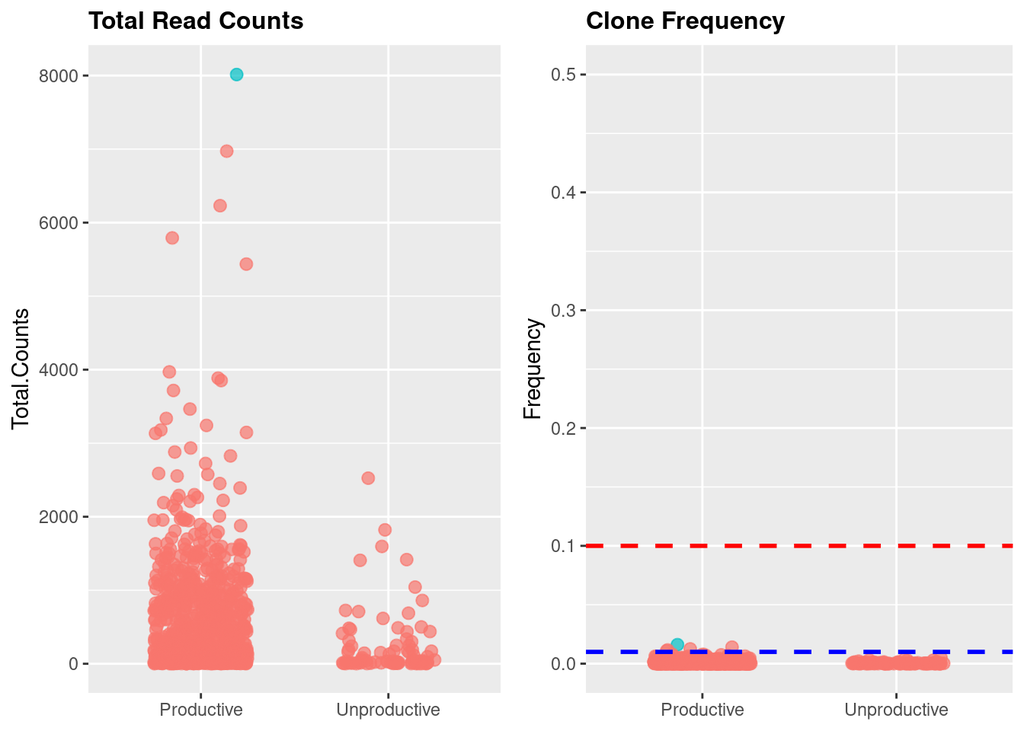

**Figure 1.** (Left panel) Total read counts per clone. (Right panel) Clone frequency indicated as ratio of read counts per clone on total read counts of the library. Red and blue dotted line are set at 10% and 1% of clone frequency. Largest clone is colored in blue. Productive reads are defined as having an in-frame CDR3 sequence and no stop codon

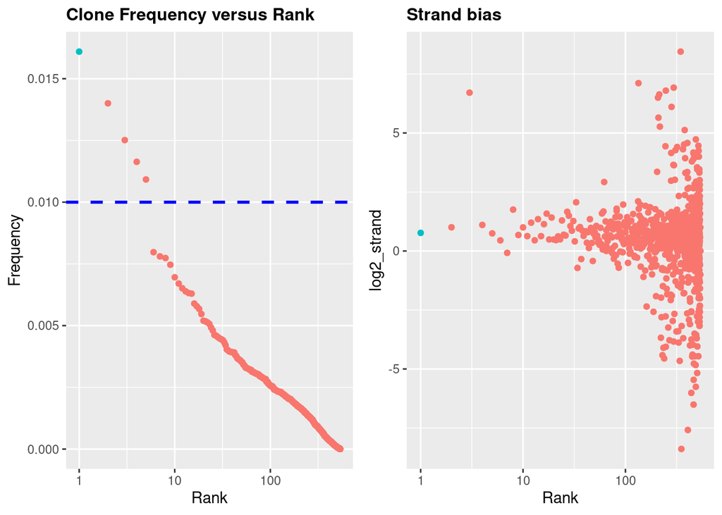

**Figure 2**. (Left panel) Clone frequency versus rank. Blue dotted line is set at 1% of clone frequency. (Right panel) Strand bias of reads is shown as log2(strand_bias) versus rank. Largest clone is colored in blue.

- Total Read Count = 1639277
- Total Number of Clones Detected = 2416
- Largest clone frequency = 2.2%
- Background:
  - rank2 clone frequency = 2%
  - rank3 clone frequency = 1.6%
  - rank4 clone frequency = 1%
  - rank5 clone frequency = 0.7%
- Ratio largest clone to:
  - rank2 clone frequency = 1.1x
  - rank3 clone frequency = 1.4x
  - rank4 clone frequency = 2.2x
  - rank5 clone frequency = 3x

#### Top 25 Clones Summary Table

| Variable | Joining | CDR3.AA | CDR3.NT | Total.Counts | Frequency | Rank |
| --- | --- | --- | --- | --- | --- | --- |
| IGKV2-30 | IGKdel |  | GCCTCTATTTCCAGACAATACGAGCCCTAGTGGCAGCC | 35451 | 0.022 | 1 |
| IGKV2-30 | IGKdel |  | CCTCCGAGCCCTAGTGGCAGCC | 32415 | 0.020 | 2 |
| IGKV2-28 | IGKJ4 | MQALQTPRS | ATGCAAGCTCTACAAACTCCCCGCTCACT | 25856 | 0.016 | 3 |
| IGKV2-30 | IGKdel |  | CCTCCGGAGCCCTAGTGGCAGCC | 15991 | 0.010 | 4 |
| IGLV3-10 | IGLJ1 | YSTDSSGNRRR | TACTCAACAGACAGCAGTGGTAATCGTAGAAGGTC | 11902 | 0.007 | 5 |
| IGKV2-30 | IGKdel |  | GCCTCAAGCCCTAGTGGCAGCC | 11473 | 0.007 | 6 |
| IGLV2-14 | IGLJ2 | SSYTSSSTLVV | AGCTCATATACAAGCAGCAGCACTCTCGTGGTA | 10962 | 0.007 | 7 |
| IGLV1-51 | IGLJ2 | GTWDSSLSAVV | GGAACATGGGATAGCAGCCTGAGTGCTGTGGTA | 8608 | 0.005 | 8 |
| IGKV2-30 | IGKdel |  | TGGCCGAGCCCTAGTGGCAGCC | 8288 | 0.005 | 9 |
| IGKV3-20 | IGKJ3 | QQYGSSPH | CAGCAGTATGGTAGCTCACCTCACT | 8105 | 0.005 | 10 |
| IGKCint | IGKdel |  | GATGCCCTAGTGGCAGCC | 8070 | 0.005 | 11 |
| IGLV2-23 | IGLJ1 | CSYAGSSTSYV | TGCTCATATGCAGGTAGTAGCACTTCTTATGTC | 7798 | 0.005 | 12 |
| IGLV3-1 | IGLJ2 | QAWDSSTVV | CAGGCGTGGGACAGCAGCACTGTGGTA | 7462 | 0.005 | 13 |
| IGKCint | IGKdel |  | TTCCTCTAGTGGCAGCC | 7408 | 0.005 | 14 |
| IGKV2-28 | IGKJ2 | MQALQTPRYT | ATGCAAGCTCTACAAACTCCTCGGTACACT | 7312 | 0.004 | 15 |
| IGKV3-11 | IGKJ4 | QQRRNWPVVT | CAGCAGCGTCGCAACTGGCCTGTGGTCACT | 6897 | 0.004 | 16 |
| IGKV2-30 | IGKJ2 | MQGTHWPPYT | ATGCAAGGTACACACTGGCCTCCGTACACT | 6760 | 0.004 | 17 |
| IGKV2-29 | IGKdel |  | CTTCCCAGCCCTAGTGGCAGCC | 6745 | 0.004 | 18 |
| IGLV2-8 | IGLJ2 | SSYAGNSVQ | AGTTCATATGCAGGCAACAGCGTCCAA | 6707 | 0.004 | 19 |
| IGKV2-30 | IGKJ4 | MQGTHWPH | ATGCAAGGTACACACTGGCCTCACT | 6642 | 0.004 | 20 |
| IGKV1-17 | IGKdel |  | TACCCCCGGAGCCCTAGTGGCAGCC | 6618 | 0.004 | 21 |
| IGKV2-30 | IGKdel |  | TGGCCCCTAGCCCTAGTGGCAGCC | 5724 | 0.003 | 22 |
| IGLV3-10 | IGLJ3 | FSTDNSGNYRV | TTCTCAACAGACAACAGTGGTAATTATAGGGTT | 5709 | 0.003 | 23 |
| IGKV2-28 | IGKdel |  | CCTCCCTAGTGGCAGCC | 5644 | 0.003 | 24 |
| IGKV2-28 | IGKJ2 | MQALQTPYT | ATGCAAGCTCTACAAACTCCGTACACT | 5596 | 0.003 | 25 |

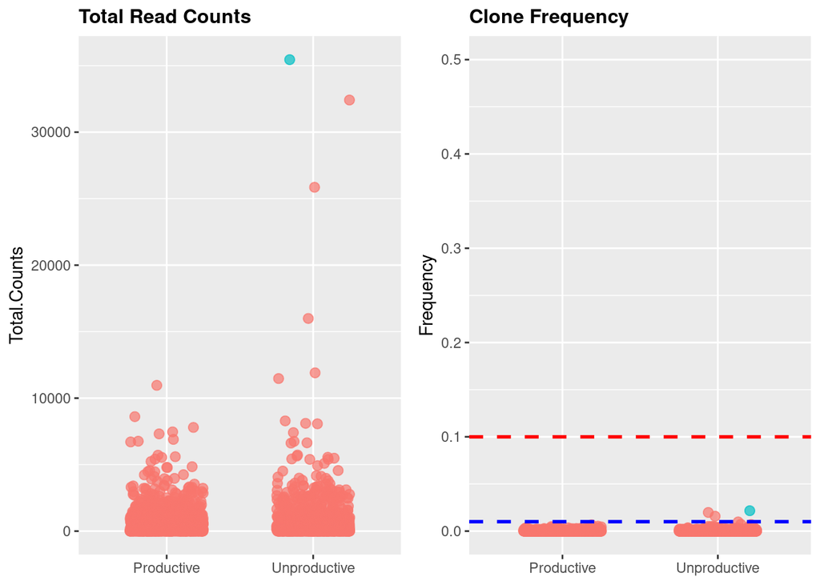

**Figure 1.** (Left panel) Total read counts per clone. (Right panel) Clone frequency indicated as ratio of read counts per clone on total read counts of the library. Red and blue dotted line are set at 10% and 1% of clone frequency. Largest clone is colored in blue. Productive reads are defined as having an in-frame CDR3 sequence and no stop codon

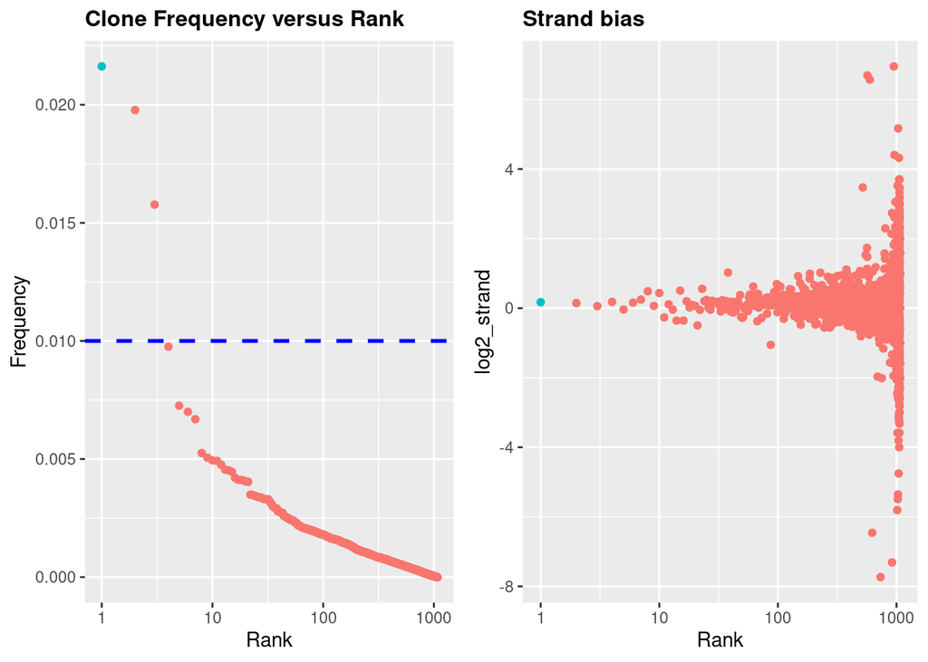

**Figure 2**. (Left panel) Clone frequency versus rank. Blue dotted line is set at 1% of clone frequency. (Right panel) Strand bias of reads is shown as log2(strand_bias) versus rank. Largest clone is colored in blue.

## Diagnose

Resultat der Parallelsequenzierung mit dem Oncomine TCR Pan-Clonality Assay (DNA):